# MUM 2024-25 Model Squeeze-and-excitation

## budowa architektury modeli konwolucyjnych

- wbudowanie elementów nauczania do architektury może wspomóc wyniki uczenia
  - znane założenie o *wbudowywaniu priorów*
  - Inception wprowadza szereg konwolucji o różnych szerokościach
    - także możliwe przez augmentację danych

## Squeeze-and-Excitation [[Hu, Shen, Albanie, Sun, Wu, *Squeeze-and-Excitation networks*, 2020]](https://arxiv.org/pdf/1709.01507.pdf)

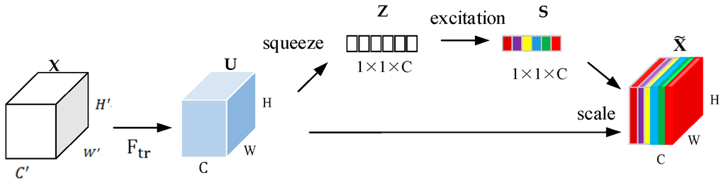

- nowy blok **squeeze-and-excitation** ma polepszyć jakość przez modelowanie zależności między kanałami
  - $F_{tr}$ jest transformacją wejścia X w mapę cech U o wymiarach $H\times{}W\times{}C$ o C kanałach
  - operacja *squeeze* $F_{sq}(\cdot)$ agreguje informacje po wymiarach przestrzennych $H\times{}W$ generując zanurzenie (embedding) $1\times1\times{}C$
    - embedding opisuje globalny rozkład opisów po kanałach
    - ten opis może być użyty we wszystkich warstwach
  - *excitation* $F_{ex}(\cdot,W)$ generuje zbiór wag, jedną na kanał
  - *skalowanie* $F_{scale}(\cdot,\cdot)$ jest aplikowana bezpośrednio do warstw
- bloki są wykorzystywane na różnych głębokościach modelu
  - na wcześniejszych wzmacnia, niezależnie od klas, wspólne dla wielu warstw informacje niskiego poziomu
  - na późniejszych staje się bardziej zależne od klasyfikacji
- wbudowanie bloków jest proste dla istniejących architektur CNN

### transformata

- wygenerowane cechy w mapie U $$u_c=v_c\ast{}X=\sum_{s=1}^{C'}v_c^s\ast{}x^s$$ gdzie $\ast$ to konwolucje, $x^s$ są z przestrzeni danych, $v_c^s$ są nauczonymi filtrami

### squeeze

- generuje statystyki $z\in\mathbb{R}^C$ **po kanałach** $$z_c=F_{sq}(u_c)=\dfrac{1}{H\times{}W}\sum_{i=1}^H\sum_{j=1}^Wu_c(i,j)$$
  - $z_c$ można traktować jako zbiór lokalnych deskryptorów których wartości opisują cały obraz

### excitation

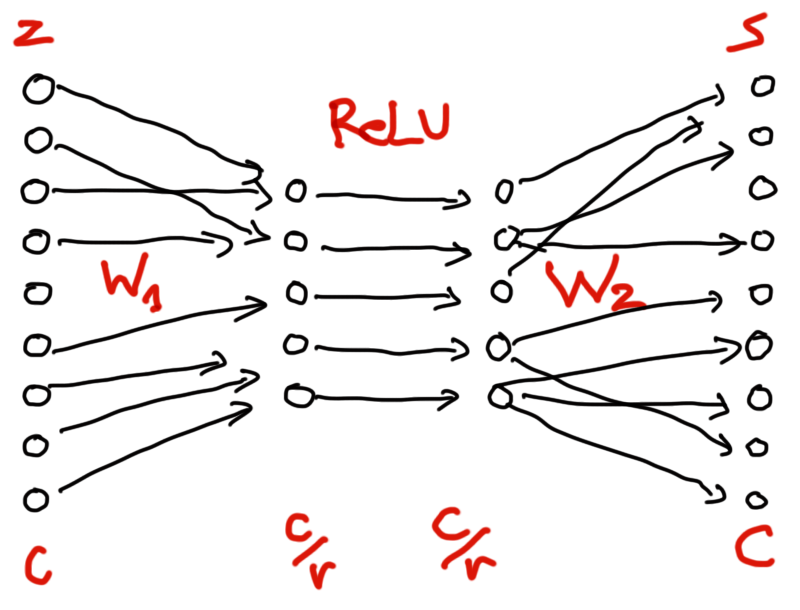

- jak wykorzystać wiedzę znalezioną w *squeeze* w pierwszym kroku?
  - funkcja musi uczyć się nieliniowych zależności między kanałami
  - te nauczone relacje nie mogą się wzajemnie wykluczać
- prosta operacja bramkująca $$s=F_{ex}(z,W)=\sigma(g(z,W))=\sigma(W_2\delta(W_1z))$$ gdzie $\sigma$ jest warstwą liniową, $\delta$ to ReLU, $W_1\in\mathbb{R}^{\frac{C}{r}\times{}C}$, $W_2\in\mathbb{R}^{C\times\frac{C}{r} }$
  - dwie warstwy liniowe wokół bottleneck z funkcją nieliniową ReLU

### skalowanie

$$F_{scale}(u_c,s_c)=s_c u_c$$ jest wymnożeniem **po kanałach** skalarnej wartości $s_c$ przez cechy warstwy $u_c\in\mathbb{R}^{H\times{}W}$

- excitation mapuje wektor z na zbiór wag
- bloki SENet wprowadzają do obliczeń informacje zależne od wejścia
- można je traktować jako **atencję** na kanałach

## złożoność

- bloki SENet można w miarę prosty sposób dobudować do różnych architektur
  - **squeeze**: operacja typu *global average pooling*
  - **excitation**: dwie małe sieci liniowe z pojedynczą aktywacją ReLU
  - **scaling**: prosta operacja wymnażania
- generalnie mało dodatkowych operacji, co potwierdzają czasy wykonania zwykle 5-10% dłuższe

## wyniki

- SE-ResNet-50 zysk jest rzędu 0.5-1.0 do ResNet-50 na błędzie top-5, osiągając wyniki podobne do ResNet-101 o znacznie większej liczbie parametrów
- podobnie SE-ResNet-101 jest odrobinę lepszy niż ResNet-152
  - jedne i drugie dla modeli zoptymalizowanych
- wciąż wymaga to jednak dobrej implementacji, oraz znalezienia dobrych hiper-parametrów

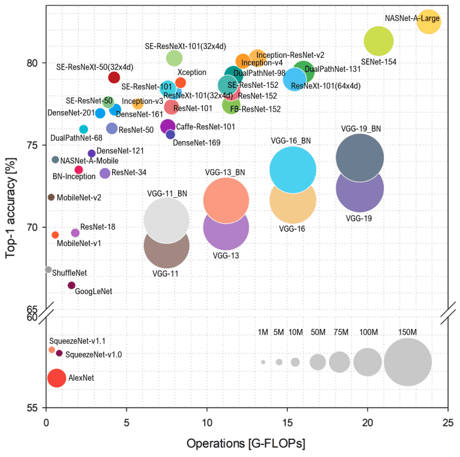

### [Porównanie wszelkich modeli dla ImageNet](https://paperswithcode.com/sota/image-classification-on-imagenet)